# Network Plots and Basic Statistics

Fan Yang

July 11, 2017

# Objecttive:

Visually interprete the co-occurrence analsis and the basic statistics of the network plots.

# Recall:

I previously introduced the co-occurrence analysis in R [here](https://github.com/germs-lab/tutorials/blob/master/2016-06-15_cooccurrence/spearman_hoeffding_tutorial.md). Therefore, I will start with generating a simulated co-occurrence relationship.

# Procedures:

## 1. Load libraries:

```r
library(Hmisc)
library(reshape2)
library(igraph)
library(sna)
library(RColorBrewer)
```

## NOTE:

Many people also like to use `GGally`, `intergraph`, and `ggnet2` for generating network plots with more of a ggplot feel. I started there and found them making network plotting more confusing and lots of times unecessary. Therefore, I am not introducing them, but you are more than welcome to explore [here](https://briatte.github.io/ggnet/)

## 2. Simulating a set of data for 4 types of relationship:

```r
set.seed(35)
x <- rnorm(100, mean = 1, sd = 9)
independent <- 0 + rnorm(100, mean = 14, sd = 9)
linear <- rnorm(100, mean = 17, sd = 5) + 0.8 * x
monotonic <- rnorm(100, mean = 800, sd = 1000) + x^3
non.mono <- rnorm(100, mean = 1000, sd = 20) - x^2

# put them all together
df <- data.frame(x, independent, linear, monotonic, non.mono)
head(df)
```

```
##            x independent    linear   monotonic  non.mono
## 1 10.5861279   11.027840 27.857859  1907.95426 902.54791
## 2  2.1959306    5.016701 13.232650   570.68036 971.16231
## 3  0.6936039   27.040713 16.851068   -18.47115 964.75030
## 4  0.5952129   23.662001 14.719917 -1023.63498 987.66191
## 5 31.0405408   18.868602 47.065058 31972.27803  37.61231
## 6 -2.5362577   16.057329  4.944066  1093.51721 994.95839
```

### 2.1. random relationship

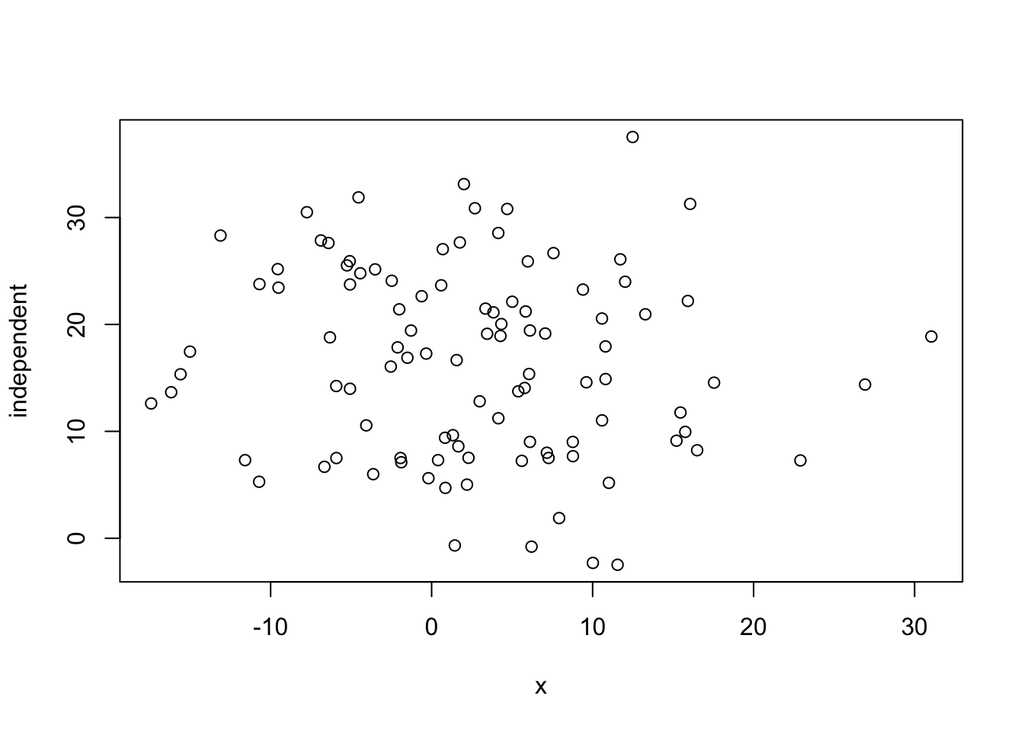

```r
plot(independent ~ x, data = df)
```

### 2.2. linear relationship

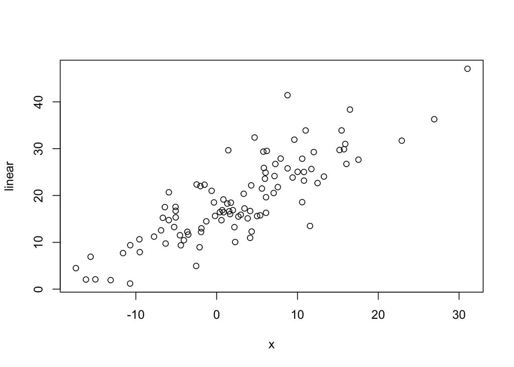

```r
plot(linear ~ x, data = df)
```

### 2.3. monotonic relationship

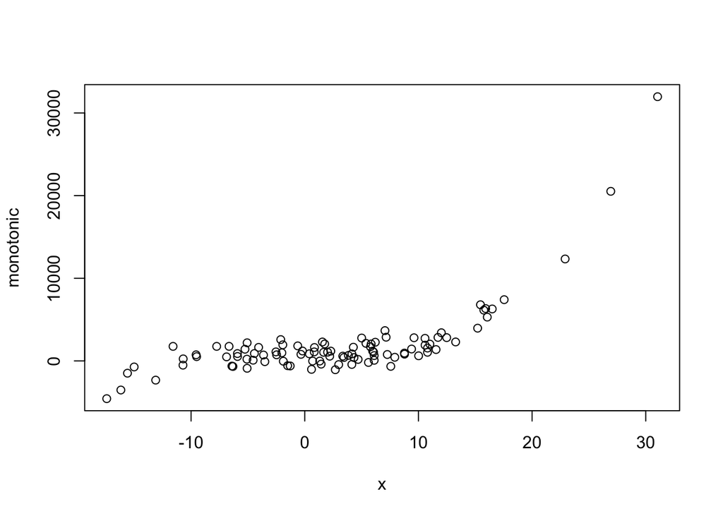

```r
plot(monotonic ~ x, data = df)
```

### 2.4. non-monotonic relationship

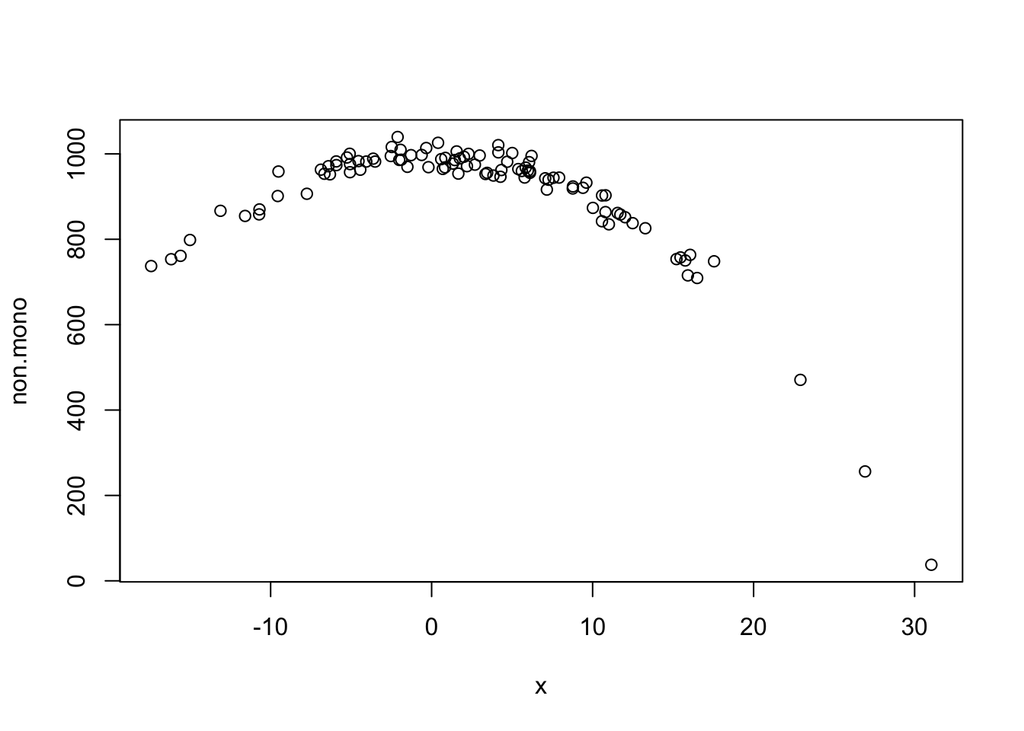

```r
plot(non.mono ~ x, data = df)
```

## 3. Evaluate their relationships:

```r
results_sp <- rcorr(as.matrix(df), type = "spearman")
results_hd <- hoeffd(as.matrix(df))

# make two seperate objects for p-value and correlation
# coefficients
rhos <- results_sp$r
sp_ps <- results_sp$P
ds <- results_hd$D
ds_ps <- results_hd$P

# going to melt these objects to 'long form' where the first
# two columns make up the pairs of OTUs, I am also removing
# NA's as they are self-comparisons, not enough data, other
# bad stuff
sp_melt <- na.omit(melt(sp_ps))
ds_melt <- na.omit(melt(ds_ps))

# creating a qvalue (adjusted pvalue) based on FDR
sp_melt$spearman_qval <- p.adjust(sp_melt$value, "fdr")
ds_melt$hoeffding_qval <- p.adjust(ds_melt$value, "fdr")
# making column names more relevant
names(sp_melt)[3] <- "spearman_pval"
names(ds_melt)[3] <- "hoeffding_pval"

# now melting the correlations
rho.melt <- na.omit(melt(rhos))
d.melt <- na.omit(melt(ds))
# add column names
names(rho.melt)[3] <- "rho"
names(d.melt)[3] <- "D"

# merging and subset for significant coefficients
sp_merged <- merge(sp_melt, rho.melt, by = c("Var1", "Var2"))
ds_merged <- merge(ds_melt, d.melt, by = c("Var1", "Var2"))
merged <- merge(sp_merged, ds_merged, by = c("Var1", "Var2"))
# subset for significant relationships
merged <- subset(merged, spearman_qval < 0.05 | spearman_qval >=
    0.05 & hoeffding_qval < 0.05 | !is.na(spearman_qval) | !is.na(hoeffding_qval))

# because both rho and D are coefficient, we can combine them
merged$coefficient_type <- ifelse(abs(merged$rho) > abs(merged$D),
    "rho", "D")
merged$coefficient <- ifelse(merged$coefficient_type == colnames(merged)[5],
    merged$rho, merged$D)

# remove
final_results <- merged[, c("Var1", "Var2", "coefficient", "coefficient_type")]
head(final_results)
```

```
##          Var1        Var2 coefficient coefficient_type
## 1 independent      linear -0.12205221              rho
## 2 independent   monotonic -0.08312031              rho
## 3 independent    non.mono  0.08303630              rho
## 4 independent           x -0.12687668              rho
## 5      linear independent -0.12205221              rho
## 6      linear   monotonic  0.51803178              rho
```

## 4. Network graphs

### 4.1. the edges:

#### 4.1.1. the base:

```r
# turn relationships into a network graph the relationships
# here are undirected
temp.graph <- graph.edgelist(as.matrix(final_results[, c(1, 2)]),
    directed = FALSE)
# E() assigns edge atributes
E(temp.graph)
```

```
## + 20/20 edges (vertex names):
##  [1] independent--linear    independent--monotonic independent--non.mono
##  [4] independent--x         independent--linear    linear     --monotonic
##  [7] linear     --non.mono  linear     --x         independent--monotonic
## [10] linear     --monotonic monotonic  --non.mono  monotonic  --x
## [13] independent--non.mono  linear     --non.mono  monotonic  --non.mono
## [16] non.mono   --x         independent--x         linear     --x
## [19] monotonic  --x         non.mono   --x
```

```r
E(temp.graph)$weight <- abs(final_results$coefficient)
```

#### 4.1.2. the most basic plot:

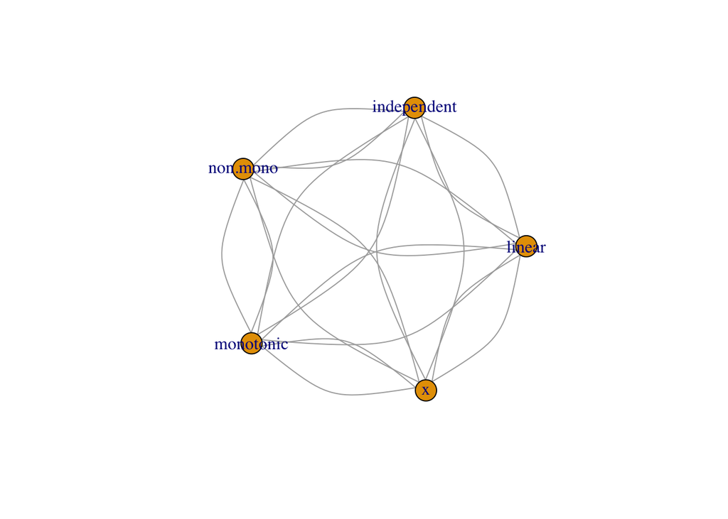

```r
plot(temp.graph)
```

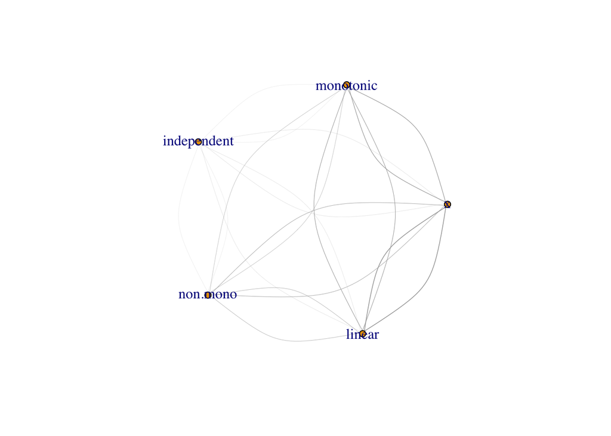

```r
# add some graph attributes
plot(temp.graph, vertex.size = 5, edge.width = E(temp.graph)$weight)
```

#### 4.1.3. the simplified plot:

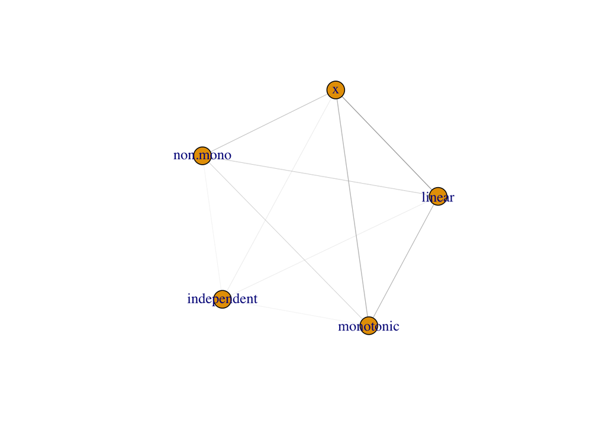

```r
# because our network is undirected, every relationship is
# duplicated. 'simplify' removes duplicated nodes and edges
temp.simplified <- simplify(temp.graph, edge.attr.comb = "mean")
# by default, it would use 'sum'
plot(temp.simplified, edge.width = E(temp.simplified)$weight)
```

#### 4.1.4. we can exaggerate the line thickness:

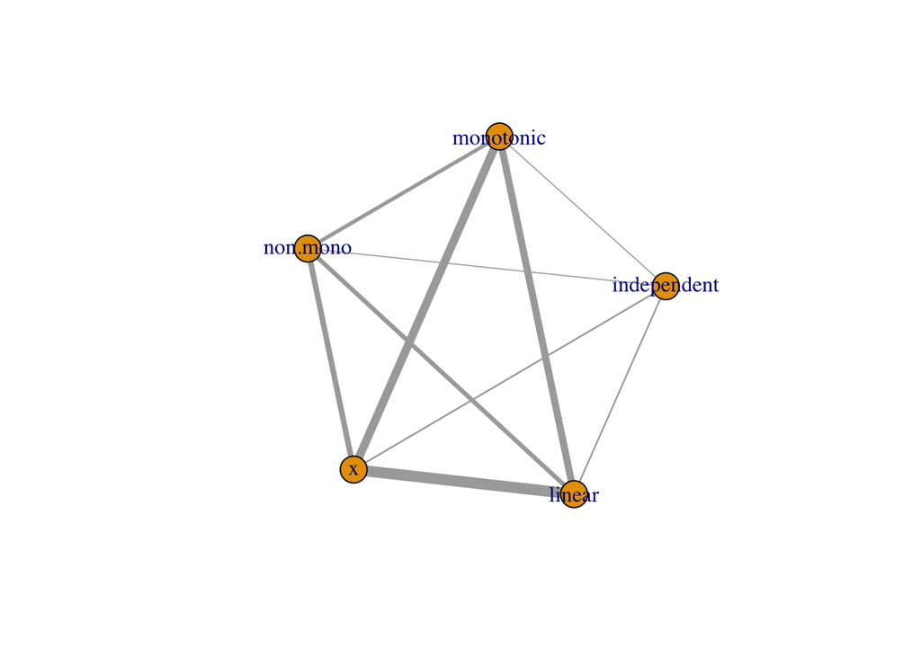

```r
E(temp.simplified)$weight <- E(temp.simplified)$weight * 10
plot(temp.simplified, edge.width = E(temp.simplified)$weight)
```

#### 4.1.5. and reposition the nodes

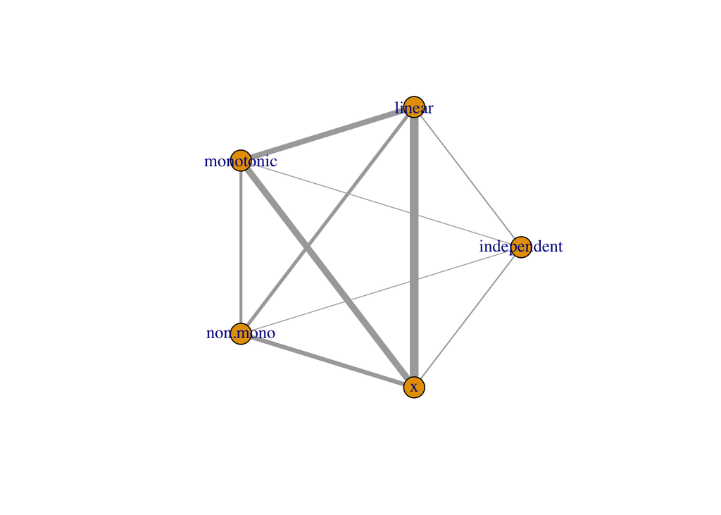

```r
plot(temp.simplified, edge.width = E(temp.simplified)$weight,
    layout = layout_in_circle)
```

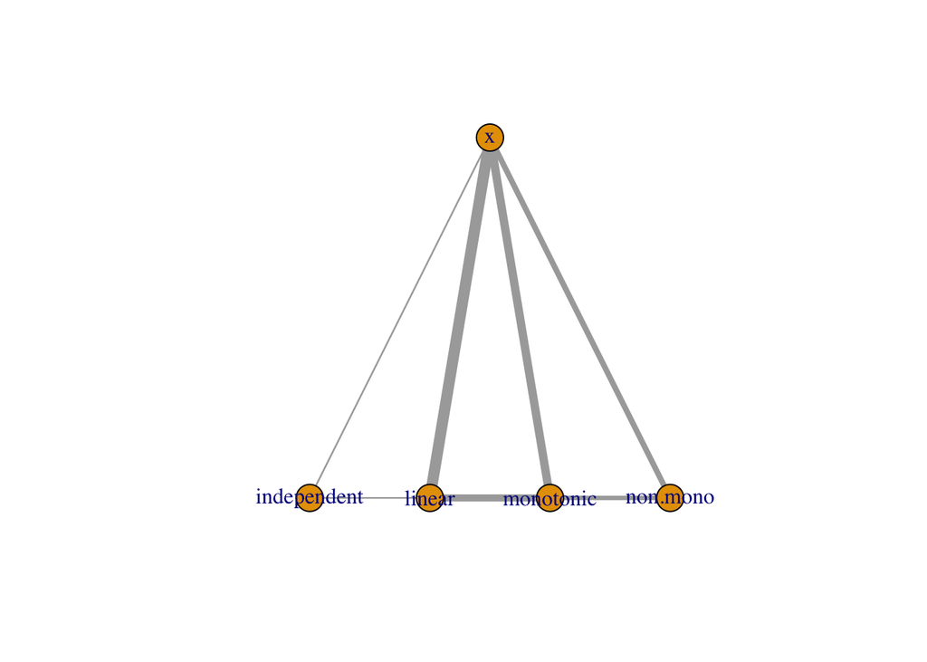

```r
plot(temp.simplified, edge.width = E(temp.simplified)$weight,
    layout = layout_as_tree)
```

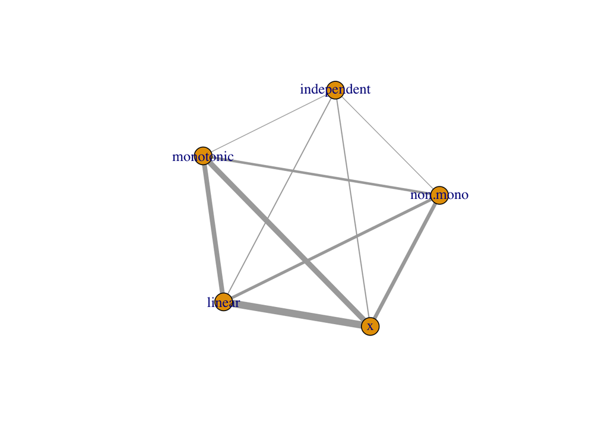

```r
plot(temp.simplified, edge.width = E(temp.simplified)$weight,
    layout = layout_nicely)
```

```r
# more here: http://igraph.org/r/doc/layout_.html
```

#### 4.1.6. we can assign different line styles to positive and negative coefficients:

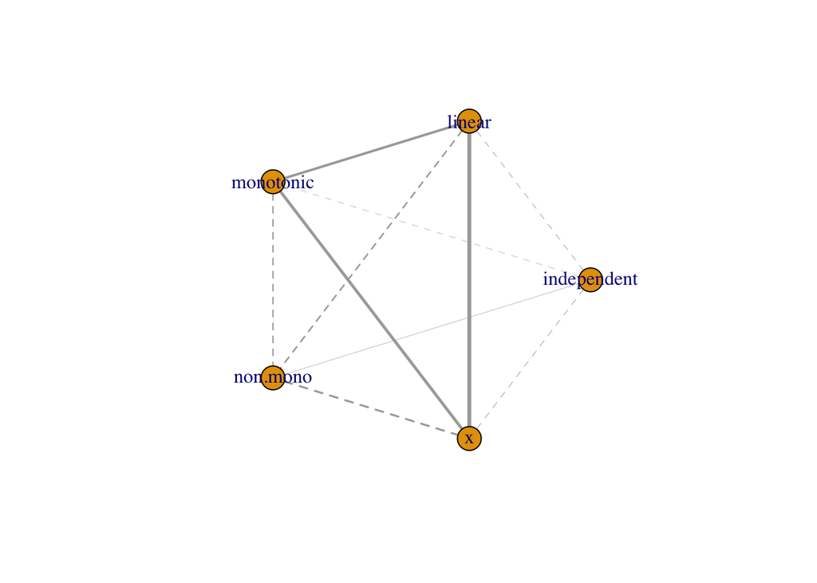

```r
E(temp.graph)$coefficient <- final_results$coefficient
E(temp.graph)$lty <- ifelse(E(temp.graph)$coefficient > 0, 1,
    2)
temp.simplified <- simplify(temp.graph, edge.attr.comb = "mean")
E(temp.simplified)$lty <- ifelse(E(temp.simplified)$coefficient >
    0, 1, 2)
plot(temp.simplified, edge.width = E(temp.simplified)$weight *
    4, layout = layout_in_circle, edge.lty = E(temp.simplified)$lty)
```

#### 4.1.7. we can assign different colors to positive and negative coefficients as well:

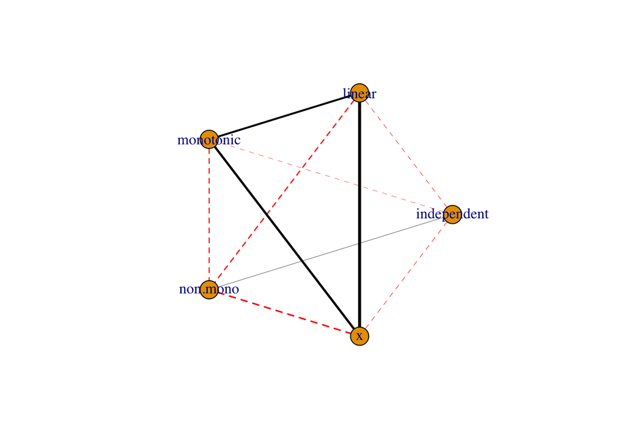

```r
E(temp.simplified)$colors <- ifelse(E(temp.simplified)$coefficient >
    0, "black", "red")
plot(temp.simplified, edge.width = E(temp.simplified)$weight *
    4, layout = layout_in_circle, edge.lty = E(temp.simplified)$lty,
    edge.color = E(temp.simplified)$colors)
```

### 4.2. the vertexes (nodes)

```r
df <- data.frame(V(temp.simplified)$name)
df
```

```
##   V.temp.simplified..name
## 1             independent
## 2                  linear
## 3               monotonic
## 4                non.mono
## 5                       x
```

#### 4.2.2. we can use `RColorBrewer` to generate colors:

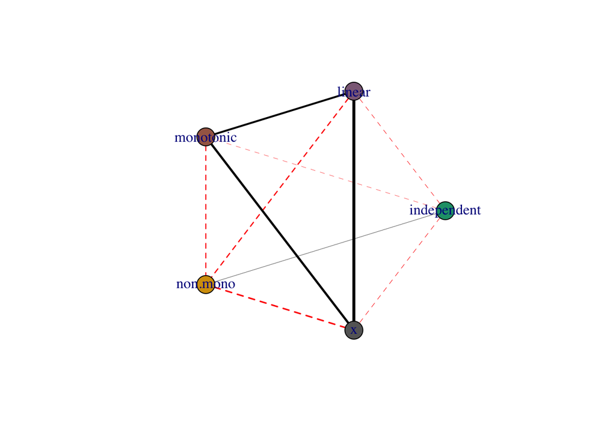

```r
colorCount <- length(unique(df[, 1]))
getPalette <- colorRampPalette(brewer.pal(8, "Dark2"))
df$colors <- getPalette(colorCount)
V(temp.simplified)$colors <- df$colors
plot(temp.simplified, edge.width = E(temp.simplified)$weight *
    4, layout = layout_in_circle, edge.lty = E(temp.simplified)$lty,
    edge.color = E(temp.simplified)$colors, vertex.color = V(temp.simplified)$colors)
```

#### 4.2.3. we can remove the node labels and add a legend:

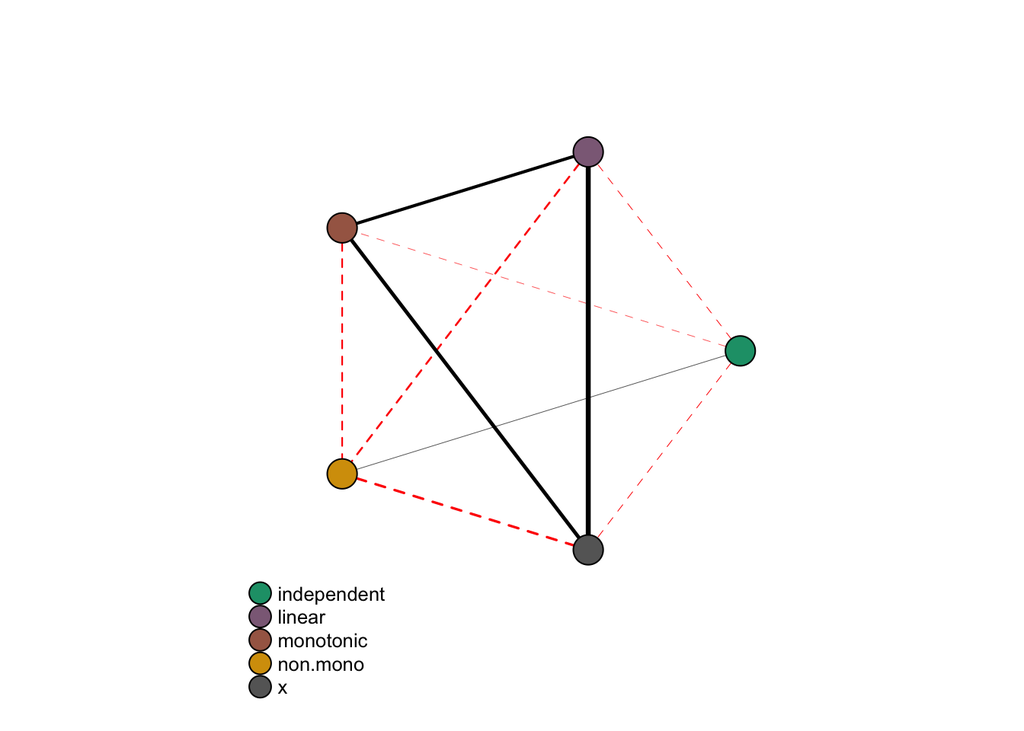

```r
plot(temp.simplified, edge.width = E(temp.simplified)$weight *
    4, layout = layout_in_circle, edge.lty = E(temp.simplified)$lty,
    edge.color = E(temp.simplified)$colors, vertex.color = V(temp.simplified)$colors,
    vertex.label = NA)
legend(x = -1.5, y = -1.1, df[, 1], pch = 21, col = "black",
    pt.bg = df$colors, pt.cex = 2, cex = 0.8, bty = "n", ncol = 1)
```

#### 4.2.4. we can update the node boarder color:

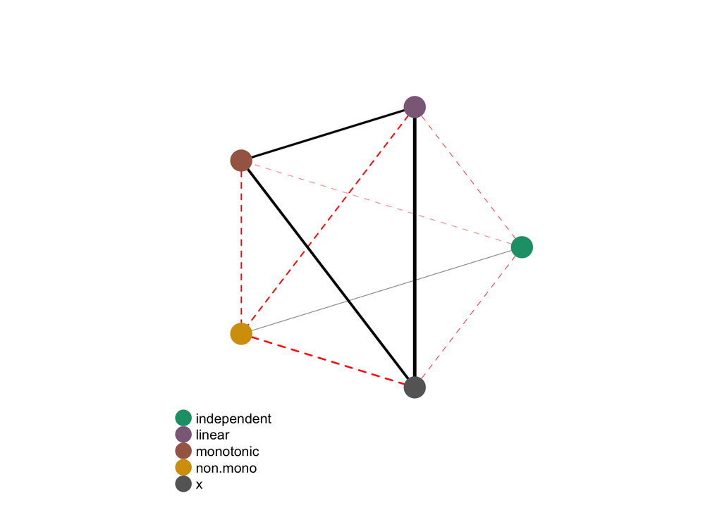

```r
V(temp.simplified)$frame.color <- df$colors
plot(temp.simplified, edge.width = E(temp.simplified)$weight *
    4, layout = layout_in_circle, edge.lty = E(temp.simplified)$lty,
    edge.color = E(temp.simplified)$colors, vertex.color = V(temp.simplified)$colors,
    vertex.frame.color = V(temp.simplified)$frame.color, vertex.label = NA)
legend(x = -1.5, y = -1.1, df[, 1], pch = 21, col = df$colors,
    pt.bg = df$colors, pt.cex = 2, cex = 0.8, bty = "n", ncol = 1)
```

## 5. Basic network stats:

### 5.1. number of nodes and edges:

```r
# number of nodes
N_nodes <- vcount(temp.graph)
N_nodes
```

```
## [1] 5
```

```r
# number of edges
N_edges <- ecount(temp.graph)
N_edges
```

```
## [1] 20
```

### 5.2. how well do our network cluster?

```r
# number of clusters
g.components <- clusters(temp.graph)
N_clusters <- g.components$no
N_clusters
```

```
## [1] 1
```

```r
# size of the largest cluster in the network
Max_csize <- max(g.components$csize)
Max_csize
```

```
## [1] 5
```

```r
# and the number of edges associated with
Max_c_edges <- ecount(induced.subgraph(temp.graph, which(g.components$membership ==
    which.max(g.components$csize))))
Max_c_edges
```

```
## [1] 20
```

### 5.3. density

the number of edges in a network divided by the total number of possible edges

```r
g.density <- graph.density(temp.graph)
g.density
```

```
## [1] 2
```

### 5.4. the paths around the network on average

```r
g.pathlength.avg <- average.path.length(temp.graph)
g.pathlength.avg
```

```
## [1] 1
```

### 5.5. centrality:

how connected is the network?

#### 5.5.1. by betweenness: the number of shortest paths from all nodes to all others that pass through that node.

```r
betcent <- centralization.betweenness(temp.graph)$centralization
betcent
```

```
## [1] 0
```

#### 5.5.2. by degree: the number of edges a node has.

```r
degcent <- centralization.degree(temp.graph)$centralization
degcent
```

```
## [1] 0
```

### 5.6. modularity:

are nodes connected within their clusters (modules) more than between clusters than they would by chance?

```
g.mod<-modularity(edge.betweenness.community(temp.graph))
g.mod
```

### 5.7. effective size:

the number of relationships between a node and other unrelated nodes OR the value of the network

```r
## effective size function ## definite a function like this
ego.effective.size <- function(g, ego, ...) {
    egonet <- induced.subgraph(g, neighbors(g, ego, ...))
    n <- vcount(egonet)
    t <- ecount(egonet)
    return(n - (2 * t)/n)
}
effective.size <- function(g, ego = NULL, ...) {
    if (!is.null(ego)) {
        return(ego.effective.size(g, ego, ...))
    }
    return(sapply(V(g), function(x) {
        ego.effective.size(g, x, ...)
    }))
}
# calculate average effective size
efsize_avg <- mean(effective.size(temp.graph, mode = "all"))
efsize_avg
```

```
## [1] -2
```

### 5.8. combine them together

```r
test <- cbind(N_nodes, N_edges, N_clusters, Max_csize, Max_c_edges,
    g.density, g.pathlength.avg, betcent, degcent, g.mod, efsize_avg)
test
```

```
##      N_nodes N_edges N_clusters Max_csize Max_c_edges g.density
## [1,]       5      20          1         5          20         2
##      g.pathlength.avg betcent degcent g.mod efsize_avg
## [1,]                1       0       0     0         -2
```